# Influence of temperature on COD removal

Caroline Van Steendam

Wednesday, October 22, 2014

Your document should layout your question in the introduction, provide a brief synopsis for why it is important, describe how you obtained the data, your general approach to analyzing the data, a summary of your results, a discussion, and mention of what your future directions would be.

## Introduction

Research with anaerobic treatment of wastewater has proven distinct advantages over the more traditional, aerobic, treatment including

- the ability to recover energy,
- the lower energy requirements, and
- the lower sludge wasting.

Low biomass growth results in the need for decoupling solid retention time from hydraulic retention time and this is where *membrane* bioreactors come into the picture: membranes are used to maintain the biomass in the system, resulting in long solid retention times while allowing for short hydraulic retention times.

AnMBRs are traditionally only considered for mesophilic industrial wastewaters, while the focus is now shifting towards the treatment of psychrophilic domestic wastewater (DWW). AnMBRs are widespread being researched at the moment and it is clear that the treatment of psychrophilic DWW is both promising and challenging at the same time. A recent study involved the use of an AnMBR for domestic wastewater, while decreasing the temperature from 12 degrees celsius to 3 degrees.

The two main questions that were the basis for this last research are the following:

1. Can the treatment of DWW with an AnMBR obtain similar effluent quality at temperatures of 9, 6, and even 3 degrees C when compared with treatment at a temperature of 12 degrees C (which is considered as the reference in this case)? This question can be formulated in a more statistical manner: do the lowest temperatures induce a difference in effluent quality when compared to the reference that is of statistical significance?
2. Can the treatment of DWW with an AnMBR obtain similar effluent quality, for the four different temperature situations? This question can be formulated in a more statistical manner: does the effluent quality of an AnMBR vary between treatment at 12 degrees C and 9, 6, or 3 degrees C?

Two separate analyses need to be performed because there are two distinct questions.

## Experiment

A bench-scale AnMBR was operated continuously for 140 days, right after performing another experiment involving the study of membrane fouling. The experiment was thus performed from day 173 until day 313, during which the temperature was step-wise decreased. The temperature was controlled using a water jacket connected to a Polystat 6-L recirculating water bath and the AnMBR was operated at a temperature of 12 degrees C see from day 173 until day 215, after which the temperature was decreased to 9 degrees C until day 251. From day 252 until day 285, the temperature was kept at 6 degrees C and was finally decreased to 3 degrees C from day 286 until day 313.

The effluent quality was monitored in several ways and included the quantification of volatile fatty acid concentrations, of chemical oxygen demand (COD), of dissolved methane, … In this specific statistical analysis, the COD results will be used to describe the effluent quality. The COD is used to quantify the degradable compounds left in the wastewater, so that low COD values correspond to low pollution.  
The AnMBR used in this experiment contains three effluent streams which were all sampled (nearly) daily after which the average COD value was calculated. The obtained average values for each temperature phase are given in Figure 1, in which the vertical lines correspond to a step-wise change in temperature (notice that not all days correspond to a COD-value). Since we are talking about a continuous experiment, the average COD values of the effluent streams are plotted versus the time (see Figure 1).

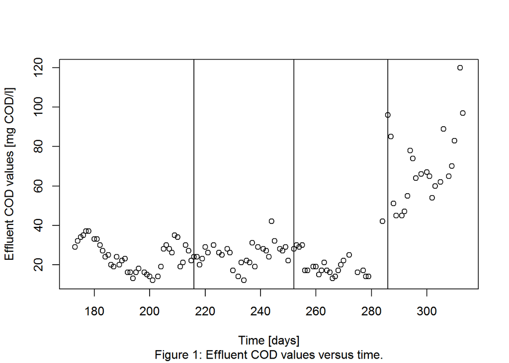

## Statistical Analysis

### First Question

We want to know if the effluent COD values of the AnMBR operated at the lower temperatures (3, 6, and 9 degrees C) are statistically different from the COD values obtained at 12 degrees C.

In order to select the correct statistical method, we first need to know if the data is normally distributed. A histogram for each temperature phase is generated (Figures 2-5). It can not indisputably be determined if the COD values at 9 degrees C are normally distributed. However, since the values for the other three temperature phases are obviously not normally distributed, the decision is made to view all phases as being not normally distributed.

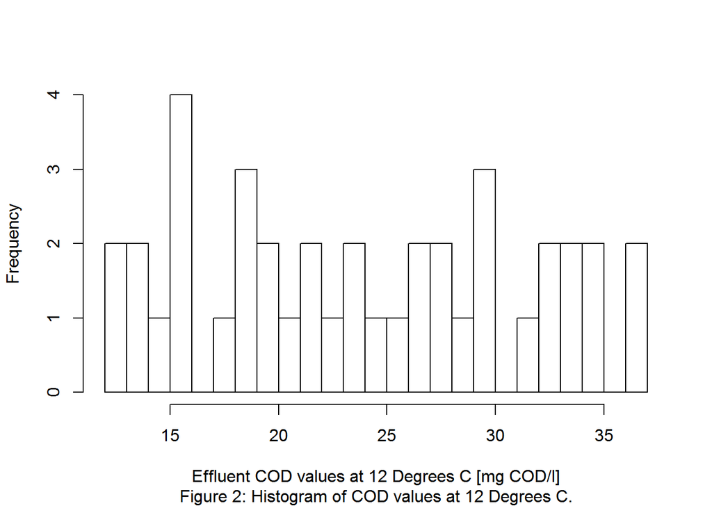

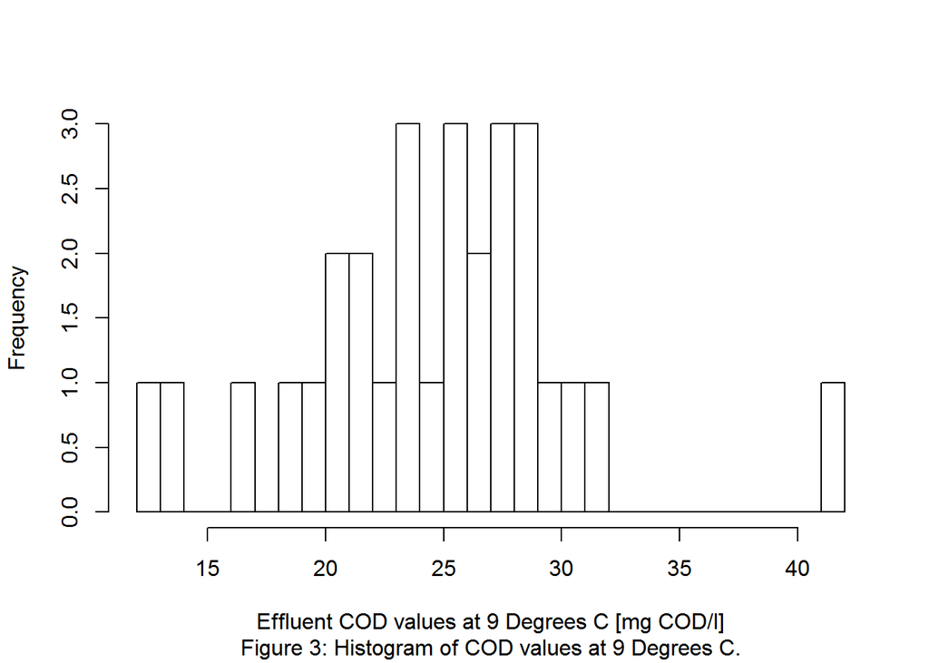

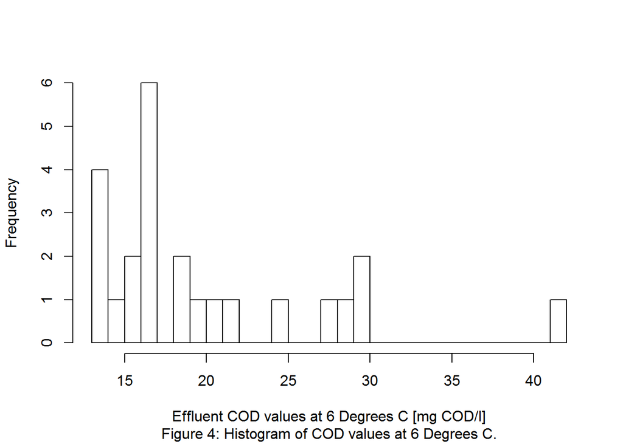

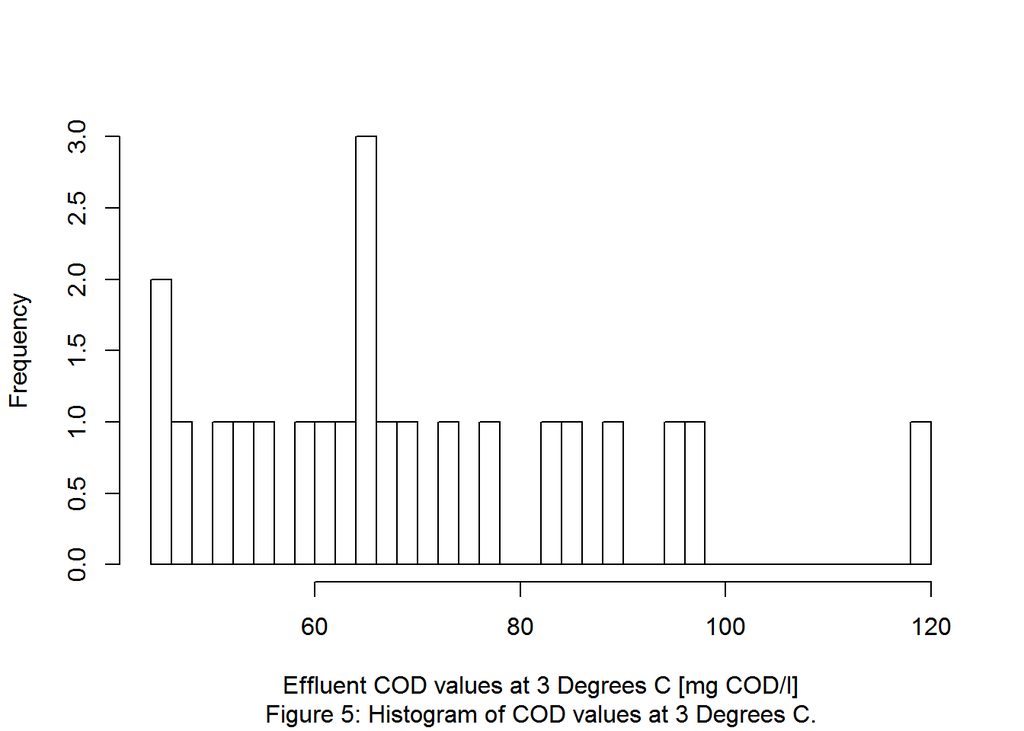

Now that it is known that the data is not normally distributed, it is clear that the two-sample Wilcoxon test needs to be performed. The two-sample test is used to test the hypothesis that two samples may be assumed to come from distributions with the same mean, whereas the Wilcoxon test is used because it is a nonparametric test. Applied to this specific situation, we need to compare both the COD values obtained at 9 and 3 degrees C with the reference situation of 12 degrees C.

```
##
##  Wilcoxon rank sum test with continuity correction
##
## data:  COD.12 and COD.9
## W = 549, p-value = 0.7105
## alternative hypothesis: true location shift is not equal to 0
```

```
##
##  Wilcoxon rank sum test with continuity correction
##
## data:  COD.12 and COD.6
## W = 633.5, p-value = 0.03355
## alternative hypothesis: true location shift is not equal to 0
```

```
##
##  Wilcoxon rank sum test with continuity correction
##
## data:  COD.12 and COD.3
## W = 0, p-value = 9.9e-11
## alternative hypothesis: true location shift is not equal to 0
```

### Second Question

We are now interested to determine if the effluent quality of an AnMBR varies between treatment at 12 degrees C and 9, 6, or 3 degrees C. It is already established that the effluent quality data is not normally distributed. Since the data consists of multiple groups and we want to know if one of them is different, a (one-way) Kruskal-Wallis test needs to be applied here.

```
##
##  Kruskal-Wallis rank sum test
##
## data:  data and g
## Kruskal-Wallis chi-squared = 58.11, df = 3, p-value = 1.488e-12
```

## Results and Discussion

When looking at Figure 1, it is clear the the COD values suddenly increase when the temperature is decreased to the low value of 3 degrees C. This corresponds to a major decrease in effluent quality and, therefore, indicates performance failure of the AnMBR at this temperature.

The Wilcoxon test confirms this impression and shows that the effluent COD values at 3 degrees C are statistically different from the reference situation (at 12 degrees C), because the corresponding p-value is below 0.05. The Wilcoxon tests additionally show that the temperature phase of 6 degrees C is statistically different from the reference situation. However, since the mean COD value of the 6 degrees-temperature phase is *lower* than the reference situation (20.375 compared 24.325) and since there is no logical explanation for the performance to *enhance* at decreased temperatures, the statistical difference in this case is irrelevant.

The outcome of the Kruskal Wallis test matches the Wilcoxon results, since the Kruskal Wallis p-value is lower than 0.05. This p-value shows that the effluent quality varies in a statistically significant manner between treatment at 12 degrees C and 9, 6, or 3 degrees C, but it does not give more specifics as to how the phases differ from each other.

It is important to keep in mind that these tests (both the Wilcoxon and Kruskal Wallis) are designed for independent data. Since the discussed experiment involves sequential operational changes to one and the same bench-scale AnMBR, the data do depend on each other. The performed tests are, therefore, not completely reliable.

## Future Directions

The experiment showed that low COD values can be reached at temperatures as low as 6 degrees C, which is very promising for psychrophilic treatment of AnMBRs. Based on other measurements done in this experiment, it can be concluded that the biofilm attached to the membrane was largely responsible for the COD removal at these low temperatures. The microbial activity in the bulk, in contrast, was negligible.

To increase the performance at 3 degrees C, new experiments are envisioned that involve enhancing the microbial activity in the bulk by applying a carrier material that supports biofilm growth. The effluent streams will be monitored in the same manner after which identical statistical tests can be performed. The hypothesis is that due to an increase in biofilm treatment, the effluent quality will not decrease as drastically when the temperature is decreased to 3 degrees C.